# project

## Throughput

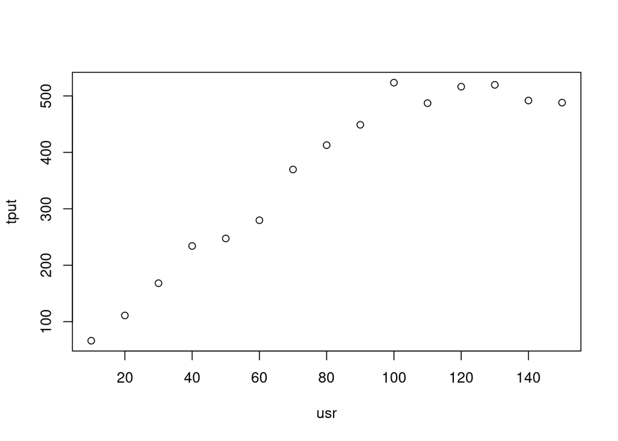

```r
throughput = read.table('throughput.dat', header = TRUE)
plot(throughput)
```

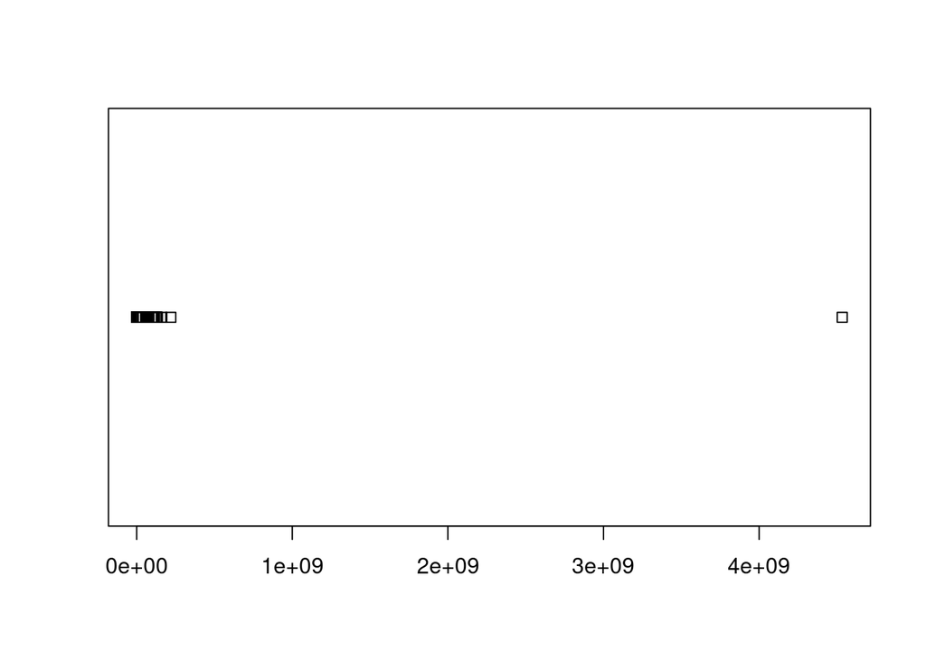

```r
filesizes = read.table('filesizes.dat')
plot(filesizes)
```

## Aula 20/05

- 1. Considere duas métricas de desempenho para um dado sistema de interesse. Que tipos de eventos (segundo a classificação da seção 6.1.1) correspondem a essas métricas? Quais estratégias de medição (segundo a classificação da seção 6.1.2) podem ser usadas para obtê-las?
- 2. Em um determinado sistema, dotado de um temporizador de intervalo com resolução de 50 µs, sabe-se que o tempo gasto para tratar uma interrupção de rede é inferior a 30 µs, mas deseja-se ter uma noção mais precisa de qual é esse tempo. Foi feito então um experimento, onde, em um conjunto de 244.918 interrupções, em 98.765 delas observou-se um avanço de um tick do temporizador em um determinado sistema. Determine um intervalo de confiança de 99% para o tempo de processamento de uma interrupção de rede nesse sistema.
- 3. Uma empresa monitora o uptime do seu enlace Internet usando a ferramenta ping, com intervalo de 10 s. Ao longo de cinco dias de monitoramento, foram observados os seguintes valores:

```r
pings = read.table('q3_pings.dat', header = TRUE)
pings
```

```
##   dia pings_enviados respostas_recebidas
## 1   1           8640                8630
## 2   2           8640                8632
## 3   3           8640                8633
## 4   4           8640                8638
## 5   5           8640                8632
```

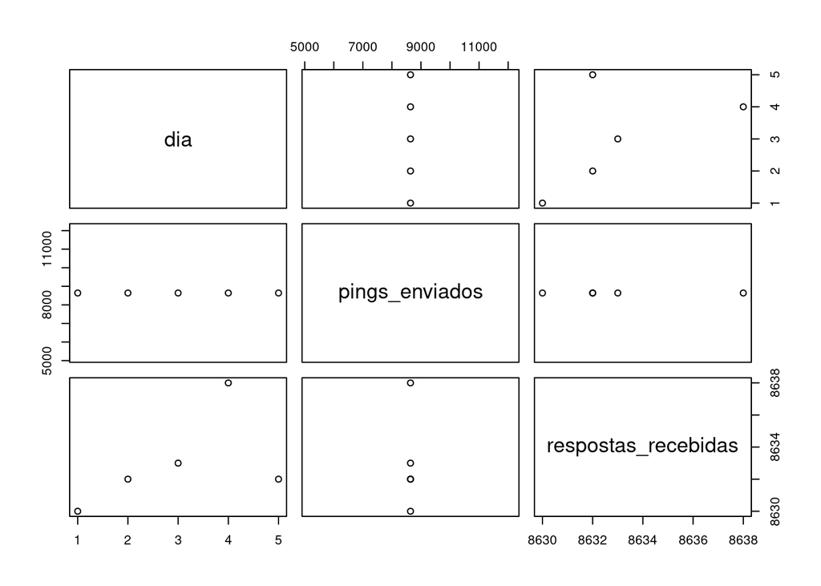

```r
plot(pings)
```